# Predicting Youtube Views Using Youtube Data

Christopher Forsythe, David Beach, Daniel Deleon

5/3/2018

## Introduction

We will be using a dataset of Youtube video statistics to predict the amount of views on a given trending video.

## Data Retrieval / Cleaning

We retrieved our data from 4 seperate datasets and combined them into one. This was so we could get a larger data set over all. The reason the dataset seperate was because the video were on youtube trending in different regions. To handle this we added a variable that would state which region each youtube video was from. Next we combine many rows together. This was because there were videos that were on the trending page for more than one day so we counted up the number of days tending and added it as a new attribute. Also while combining rows we took the max like, dislikes, comments, and views varible from each video and added them as new attributes as well. Finally we added a constant (1) to the variables max_like, max_dislike, max_comments, and max_views to allow for log tranformation/scaling.

```r
dat = read.csv("https://github.com/cforsythe/ViewPredictor/raw/master/USvideos.csv")
dat1 = read.csv("https://github.com/cforsythe/ViewPredictor/raw/master/CAvideos.csv")
dat2 = read.csv("https://github.com/cforsythe/ViewPredictor/raw/master/FRvideos.csv")
dat3 = read.csv("https://github.com/cforsythe/ViewPredictor/raw/master/DEvideos.csv")
dat$region=0
dat1$region=1
dat2$region=2
dat3$region=3
dat = rbind(dat, dat1, dat2, dat3)
dat$thumbnail_link = NULL
dat$video_error_or_removed = NULL
#create table of how many times a video_id appears
days_trending = data.frame(table(dat$video_id))
max_likes = aggregate(likes ~ video_id, data=dat, max)
max_dislikes = aggregate(dislikes ~ video_id, data=dat, max)
max_comments = aggregate(comment_count ~ video_id, data=dat, max)
max_views = aggregate(views ~ video_id, data=dat, max)
colnames(days_trending) = c("video_id", "days_trending")
colnames(max_likes) = c("video_id", "max_likes")
colnames(max_dislikes) = c("video_id", "max_dislikes")
colnames(max_comments) = c("video_id", "max_comments")
colnames(max_views) = c("video_id", "max_views")
dat = merge(dat, days_trending)
dat = merge(dat, max_likes)
dat = merge(dat, max_dislikes)
dat = merge(dat, max_comments)
dat = merge(dat, max_views)
dat$views = NULL
dat$likes = NULL
dat$dislikes = NULL
dat$comment_count = NULL
dat = dat[!duplicated(dat$video_id),]
dat$description = gsub('\\\\n',' ', dat$description)
dat$max_likes = dat$max_likes + 1
dat$max_comments = dat$max_comments + 1
dat$max_dislikes = dat$max_dislikes + 1
dat$max_views = dat$max_views + 1
dat$region = as.factor(dat$region)
dat$days_trending = as.factor(dat$days_trending)
```

# Density Plot

The denstiy of views plot shows that a large portion of the view counts are below 200,000 views.

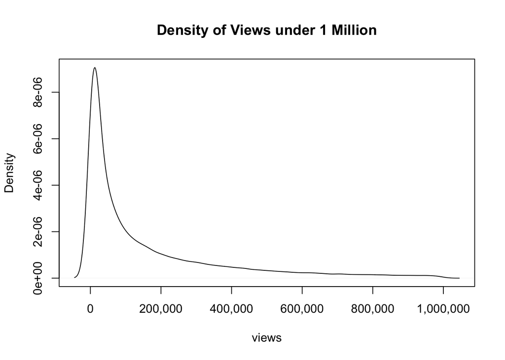

```r
plot(density(dat[dat$max_views < 1000000,]$max_views),xlab = "views",main = "Density of Views under 1 Million",xaxt = "n")
axis(1,at = seq(0,1000000,200000), labels= c("0","200,000","400,000","600,000","800,000","1,000,000"))
```

#Trending Videos

Understanding the channels with the most trending videos might help us predict views better.

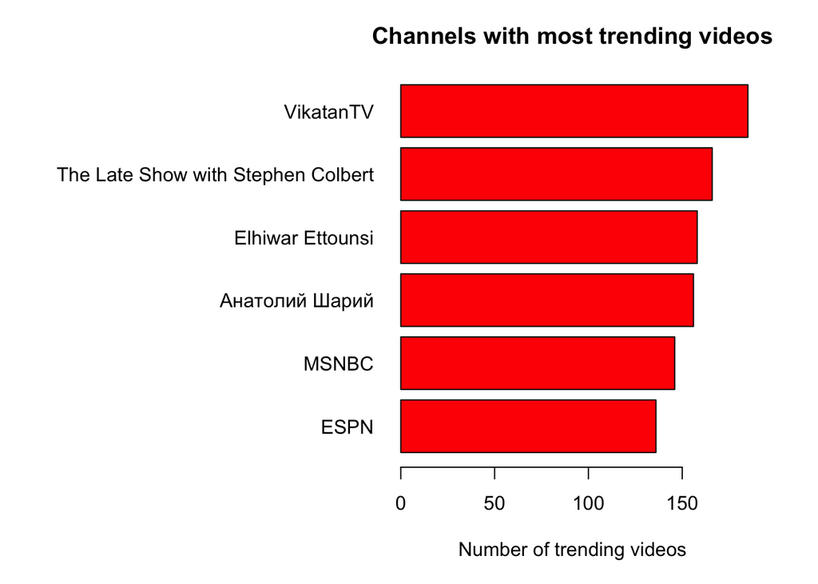

```r
par(mar=c(5, 17, 3, 3))
barplot(tail(sort(table(dat$channel_title))), las = 1, horiz=T, main="Channels with most trending videos", xlab="Number of trending videos", col="red")
```

# Categories

We thought it would be interesting to take a look at avg views per category to see if there were any significant differences. A problem we ran into is that the te_dat split had more levels than the test set and the model couldn’t predict for the extra levels.

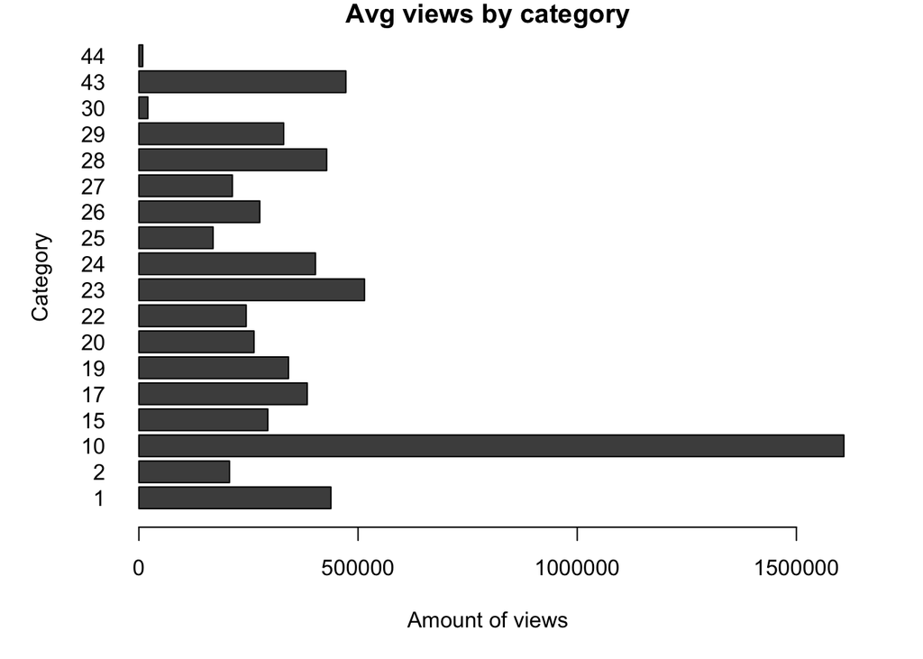

```r
par(mar=c(5, 5, 1, 3))
avg_views_by_cat = data.frame(aggregate(max_views ~ category_id, data=dat, mean))
plot_data = t(avg_views_by_cat[-1])
colnames(plot_data) = avg_views_by_cat[,1]
barplot(plot_data, horiz=T, las=1, xlab="Amount of views", ylab="Category", main="Avg views by category")
```

## Splitting

Here we split the data

```r
set.seed(123)
source("lin-regr-util.R")
splits = split_data(dat)
tr_dat = splits[[1]]
te_dat = splits[[2]]
```

## Initial Model

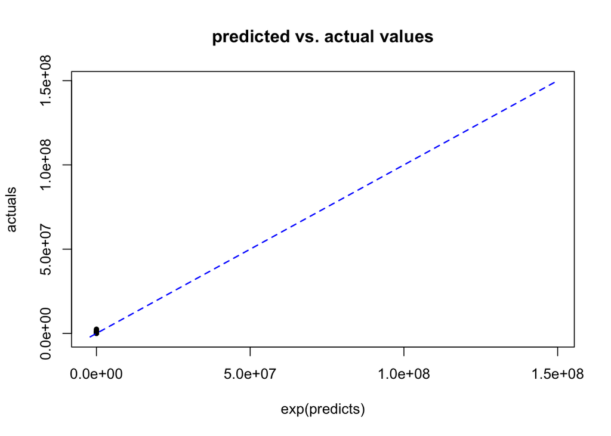

```r
fit = lm(max_views ~ days_trending + max_comments + max_likes + max_dislikes, dat=tr_dat)
rmse = function(actuals, predicts){
  sqrt(mean((actuals-predicts)^2))
}
pred_vs_actual = function(predicted, actual){
  rng = range(c(predicted, actual))
  plot(actuals~exp(predicts), pch=20,
  xlim=rng, ylim=rng,
  main="predicted vs. actual values")
  lines(c(rng[1], rng[2]),
  c(rng[1], rng[2]),
  lty=2, col="blue", lwd=1.5)
}
actuals = te_dat$max_views
predicts = predict(fit, newdat=te_dat)
pred_vs_actual(predicts, actuals)
```

```r
pred_rmse = rmse(actuals, predicts)
print(paste0("RMSE: ", round(pred_rmse)))
```

```
## [1] "RMSE: 1176320"
```

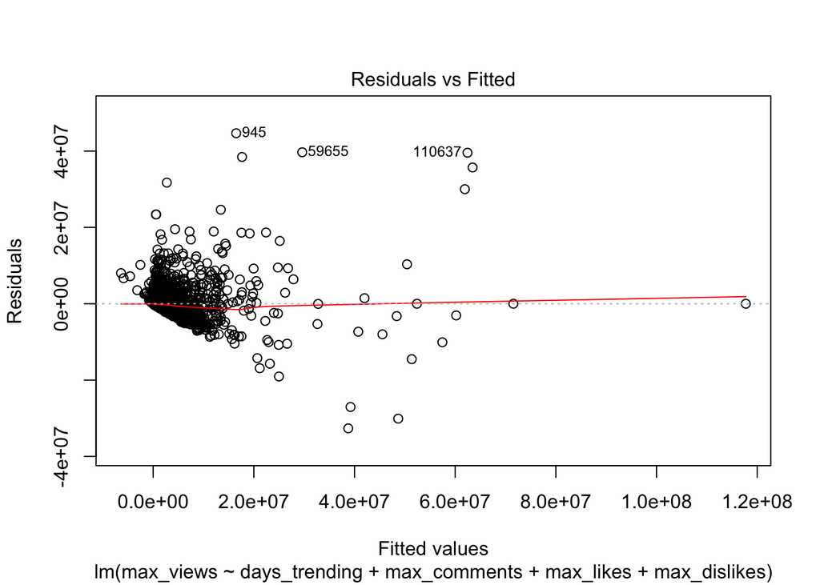

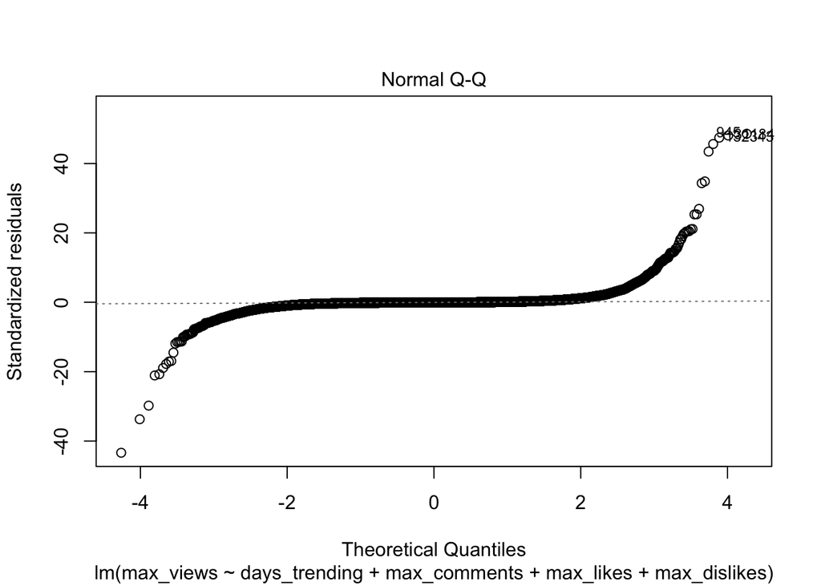

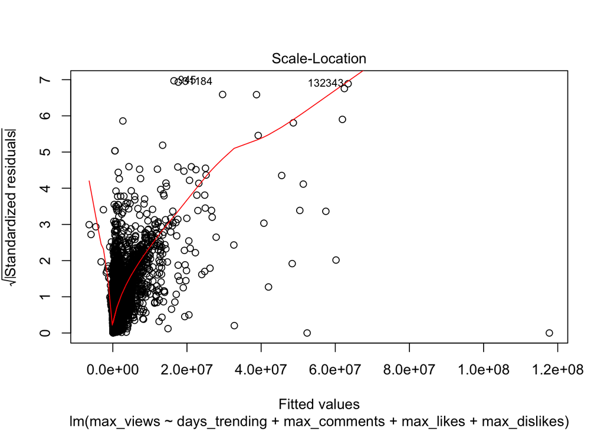

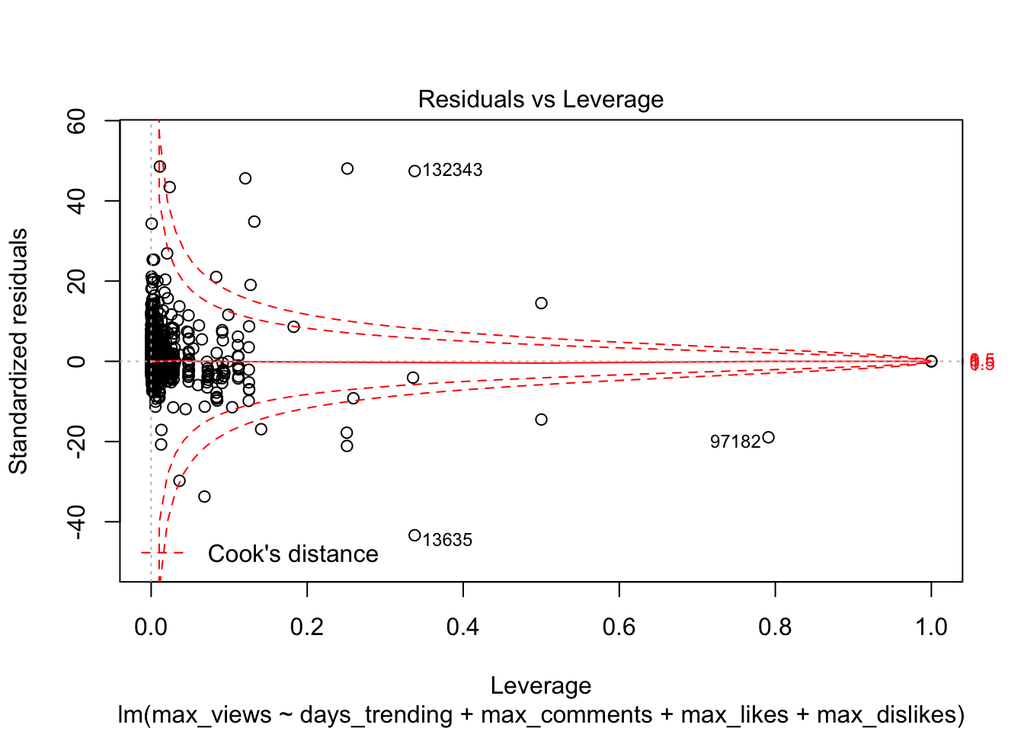

```r
plot(fit)
```

## Model 1

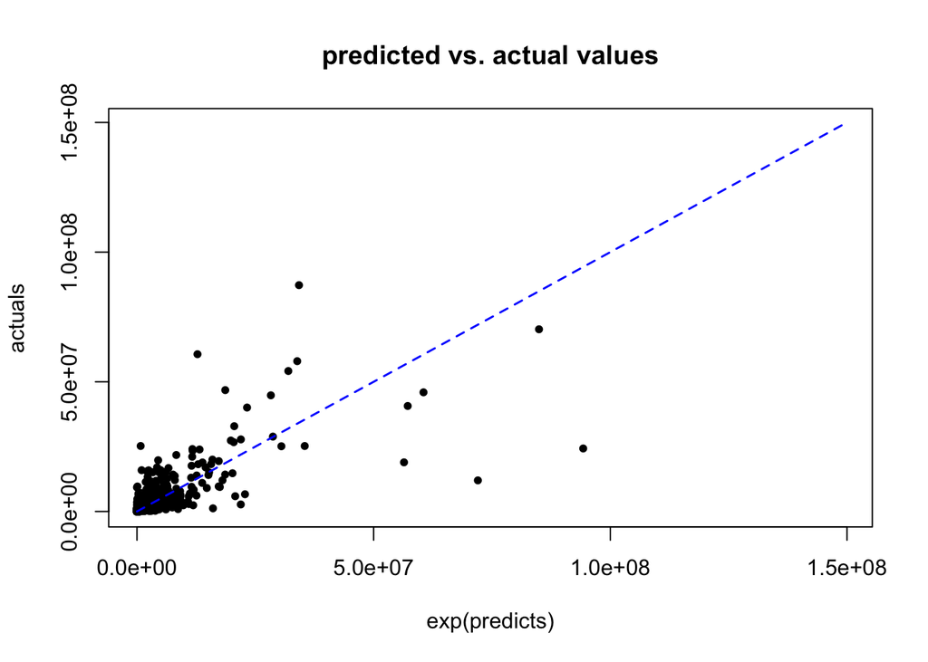

```r
fit1 = lm(log(max_views) ~ log(max_comments) + log(max_likes) + log(max_dislikes) + region + days_trending , dat=tr_dat)
actuals = te_dat$max_views
predicts = predict(fit1, newdat=te_dat)
pred_vs_actual(predicts, actuals)
```

```r
pred_rmse = rmse(actuals, exp(predicts))
print(paste0("RMSE: ", round(pred_rmse)))
```

```
## [1] "RMSE: 1398245"
```

# Model Analysis

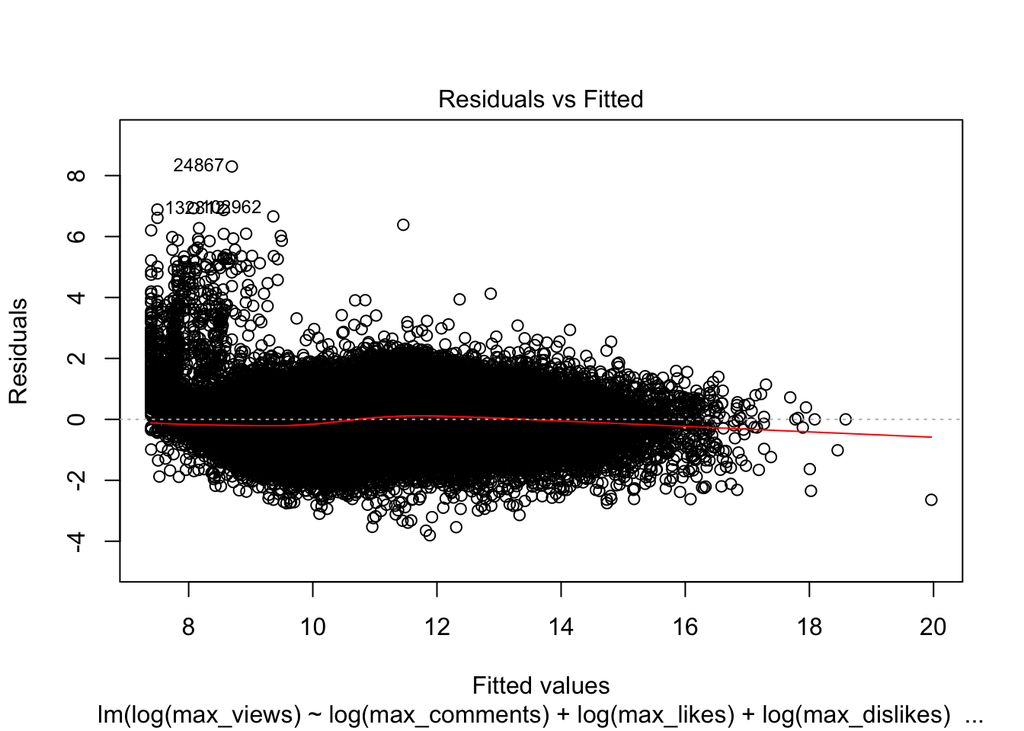

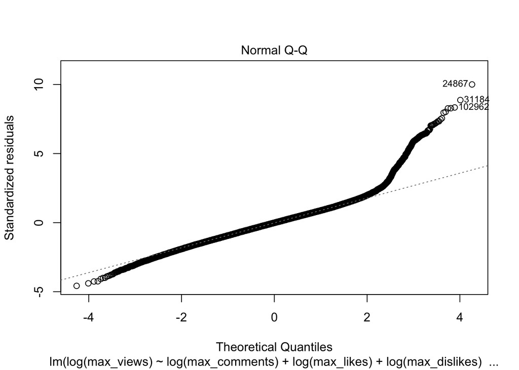

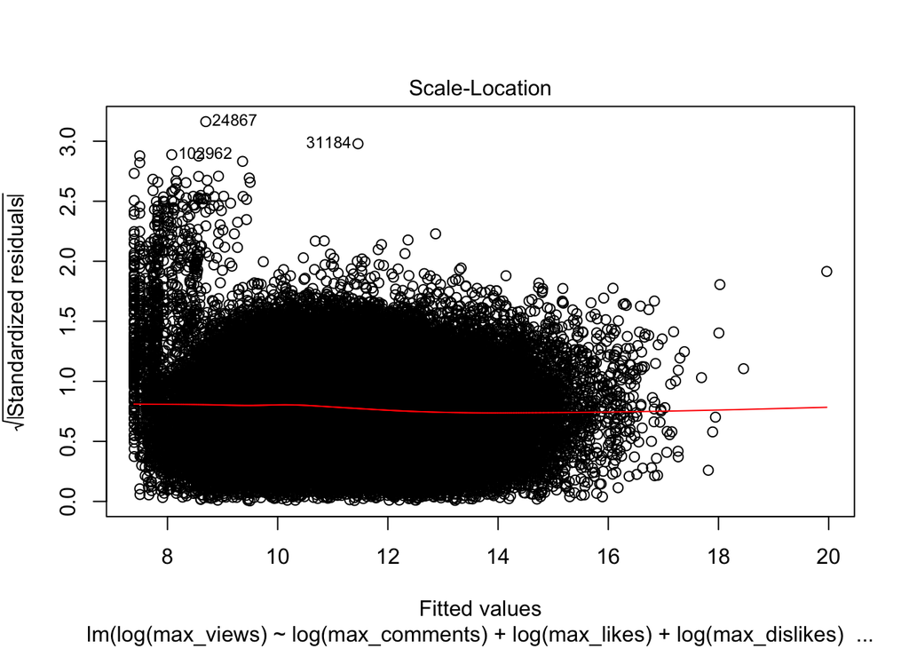

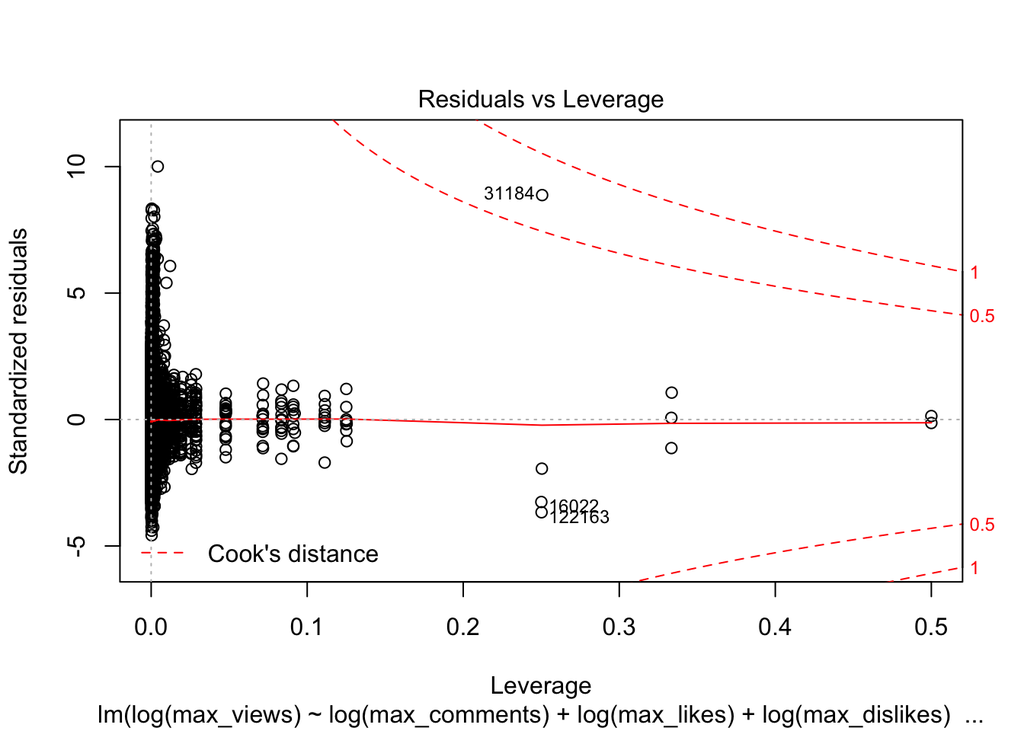

```r
plot(fit1)
```